# Operating Model for approximating GRYM for the Antarctic krill (*Euphausia superba*) in southwest Atlantic (FAO Area 48.1)

# Historical Simulation Plots

## Historical Time-Series

### Spawning Biomass

#### Depletion

Time-series plots of SB/SB0:

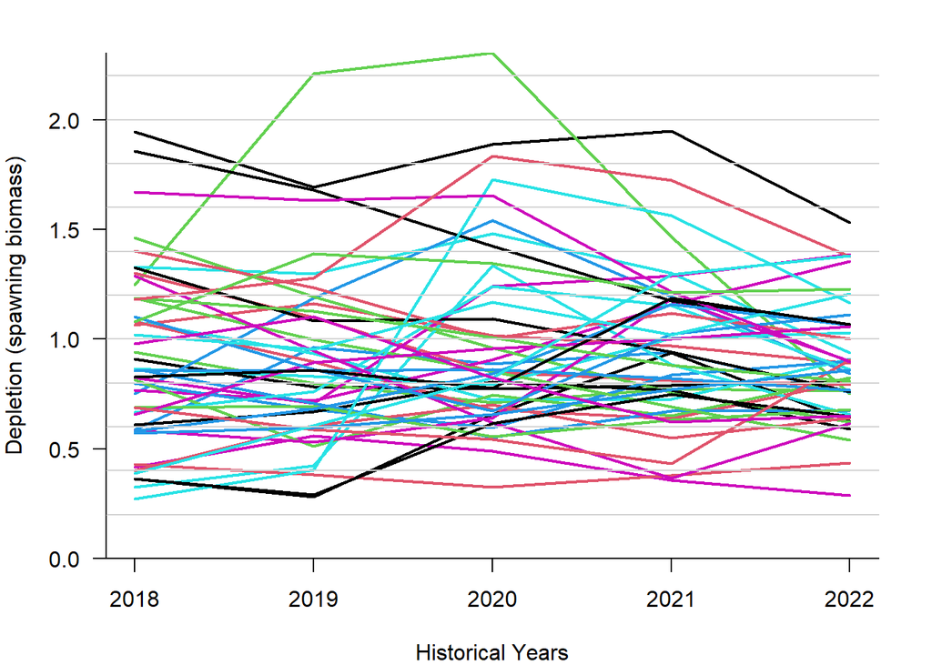

#### Absolute

Time-series plots of absolute SB:

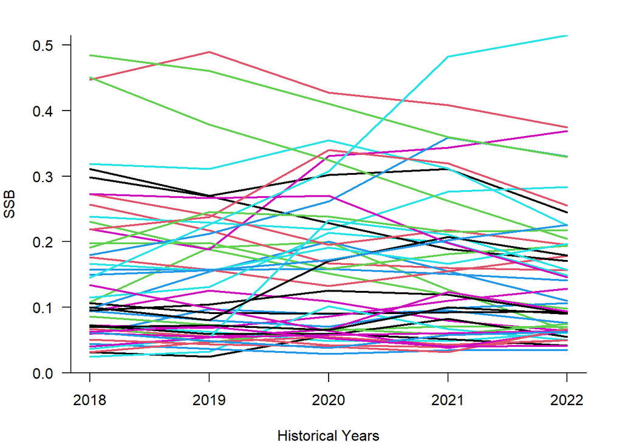

### Vulnerable Biomass

#### Depletion

Time-series plots of VB/VB0:

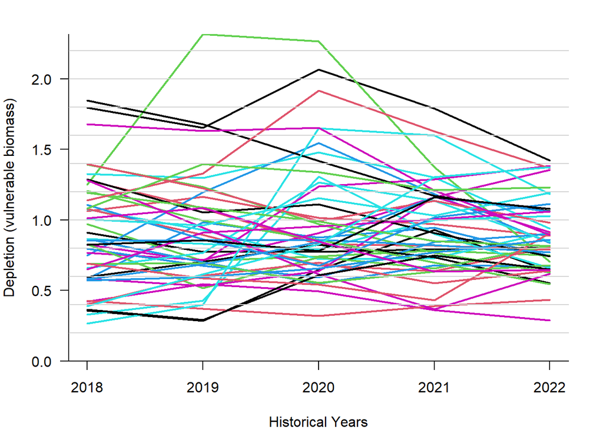

#### Absolute

Time-series plots of absolute VB:

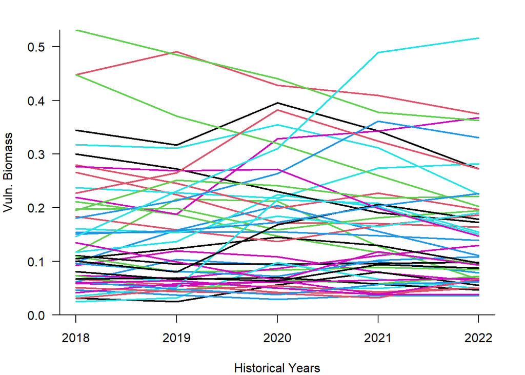

### Total Biomass

#### Depletion

Time-series plots of B/B0:

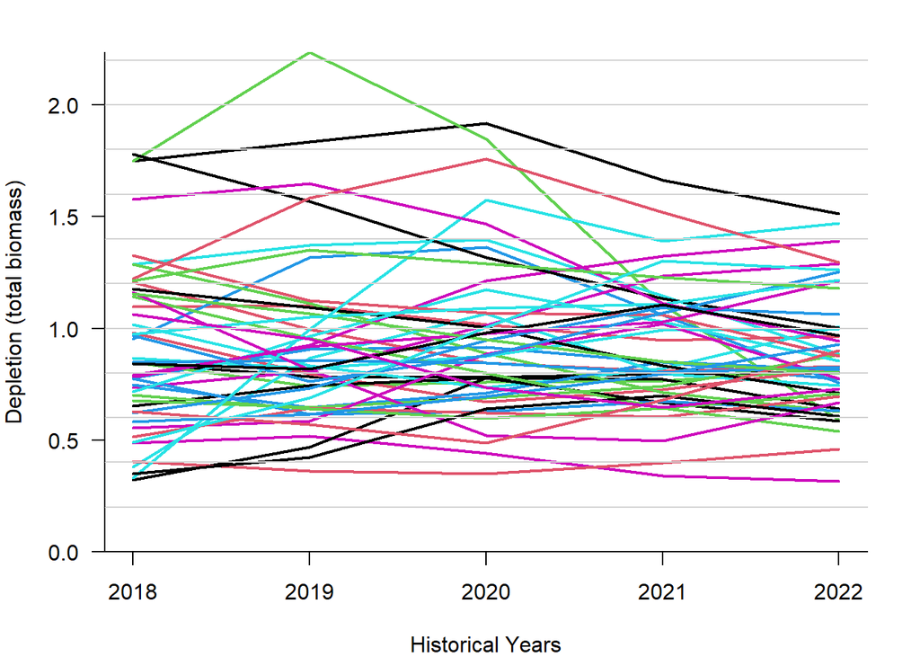

#### Absolute

Time-series plots of absolute B:

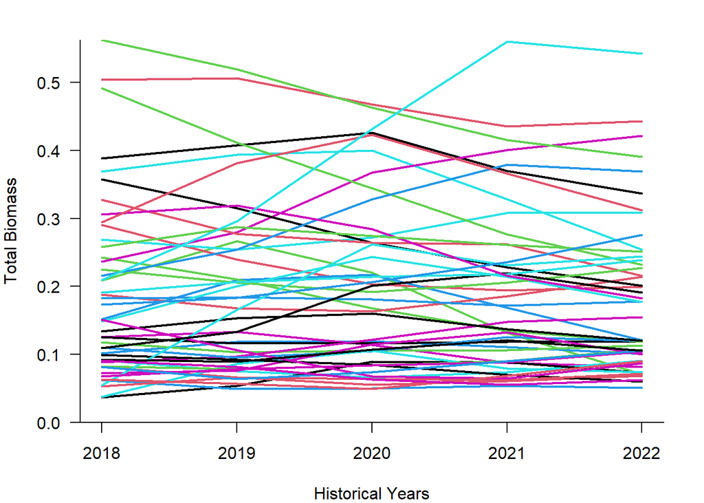

### Recruitment

#### Relative

Time-series plot of recruitment relative to R0:

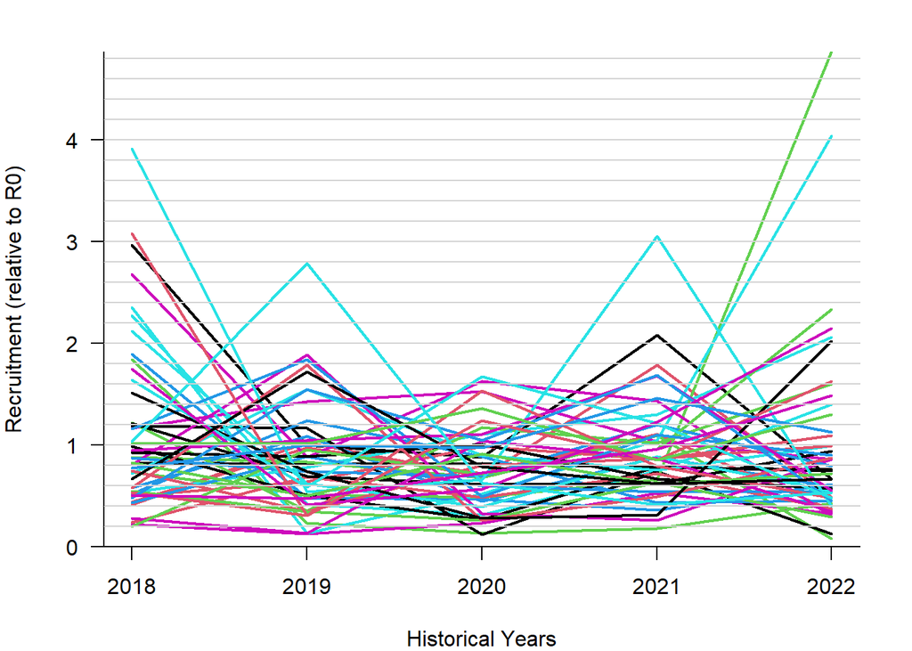

#### Absolute

Time-series plot of absolute recruitment:

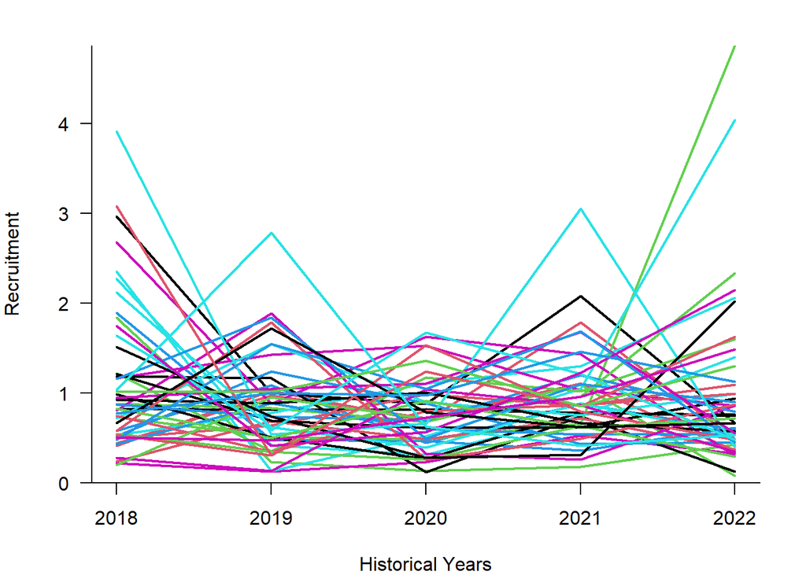

### Catch

#### Relative

Time-series of catch relative to the current year:

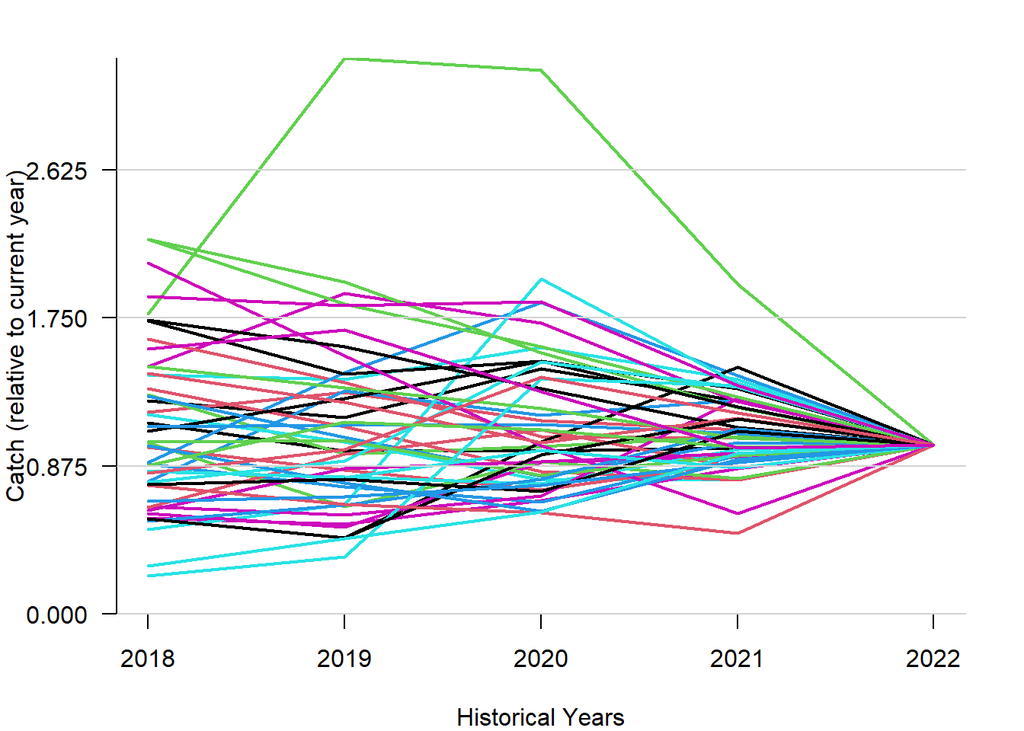

#### Absolute

Time-series of absolute catch:

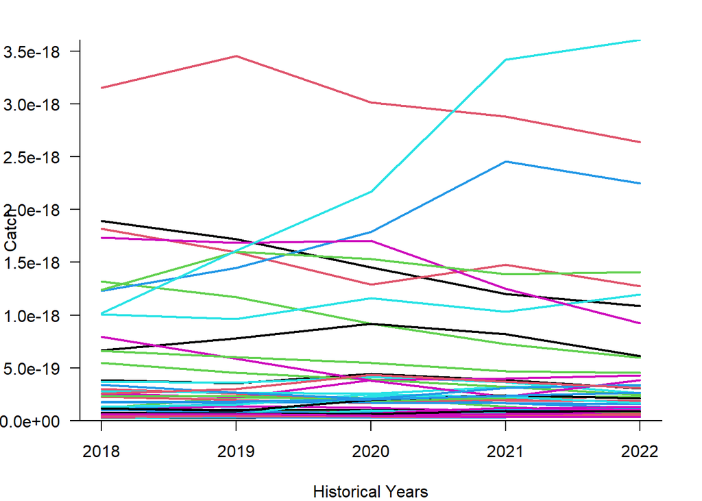

### Historical Fishing Mortality

#### Historical Time-Series

Time-series of historical fishing mortality:

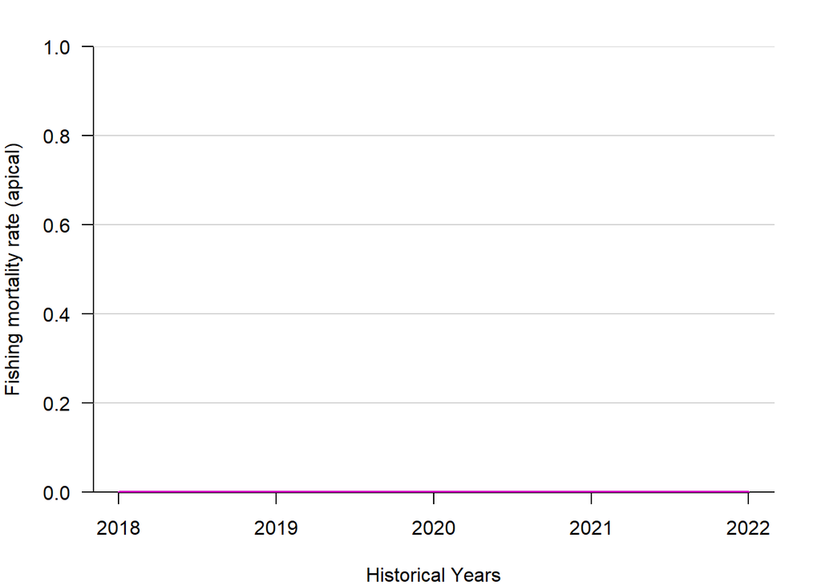

# References

Constable, A.J., de la Mare, W.K., 1996. A generalised model for evaluating yield and the long-term status of

fish stocks under conditions of uncertainty. CCAMLR Sci. 3, 31–54.

Maschette, D., Wotherspoon, S. 2021. Use of parameters within Euphausia superba GRYM simulations. WG-FSA-2021/40. Commission for the Conservation of Antarctic Marine Living Resources.

Maschette, D., Wotherspoon, S., Kawaguchi, S., Ziegler P. 2021. GRYM assessment for Subarea 48.1 Euphausia superba populations. WG-FSA-2021/39.Commission for the Conservation of Antarctic Marine Living Resources.

Pavez, C., S. Wotherspoon, D. Maschette, K. Reid, and K. Swadling. 2021. Recruitment Modelling for Euphausia Superba Stock Assessments Considering the Recurrence of Years with Low Recruitment. WG-SAM-2021/09. Commission for the Conservation of Antarctic Marine Living Resources.

Thanassekos, S., K. Reid, S. Kawaguchi, S. Wotherspoon, D. Maschette, P. Ziegler, D. Welsford, G. Watters, D.

Kinzey, C. Reiss, C. Darby, P. Trathan, S. Hill, T. Earl, S. Kasatkina and Y.-P. Ying. 2021. Grym

parameter values for Subareas 48.1, 48.2 and 48.3. WG-SAM-2021/12.